# 🧠 AIDE Defense v1

### Autonomous Intelligence for Decision Evaluation (Advisory Only)

## Overview

**AIDE Defense v1** is a human-in-the-loop **strategic decision intelligence system** designed to help policymakers, researchers, and institutions evaluate high-stakes decisions under uncertainty.

Rather than predicting outcomes or automating actions, AIDE Defense focuses on **how decisions propagate risk** across geopolitical, economic, and systemic dimensions — and whether those decisions remain robust when assumptions fail or are misinterpreted.

AIDE Defense is **not a weapon system**.  
It does not execute, command, or control any real-world operations.  
It exists solely to **support human judgment**.

## Core Problem

In national and global crises, failures rarely come from a lack of information.  
They arise from:

- Overconfidence in incomplete data
- Ignoring second- and third-order effects
- Misinterpretation of intent by adversaries
- Fragile decisions that collapse under uncertainty

AIDE Defense was built to address these exact failure modes.

## What AIDE Defense Does

AIDE Defense evaluates strategic decisions through multiple complementary lenses:

### 1. Decision-Centric Evaluation

- Accepts abstract decision vectors instead of commands
- Evaluates consequences without executing actions
- Keeps humans as the final authority

### 2. Escalation & Systemic Risk Modeling

- Models how escalation propagates across alliances and systems
- Surfaces indirect and second-order effects
- Integrates economic, disaster, and geopolitical stressors

### 3. Nuclear Miscalculation Risk (Decision-Level)

- Models risk arising from miscommunication and doctrine rigidity
- Does **not** model weapons, targeting, or force execution

### 4. Uncertainty & Confidence Awareness

- Quantifies uncertainty instead of hiding it
- Outputs confidence scores alongside every recommendation
- Refuses to recommend when confidence is insufficient

### 5. Robustness & Regret Analysis

- Stress-tests decisions under noise and assumption failure
- Identifies worst-case outcomes and volatility
- Highlights decisions that fail gracefully over those that optimize narrowly

### 6. Adversarial Misinterpretation Modeling

- Estimates how actions may be misunderstood by others
- Accounts for signaling ambiguity, doctrine mismatch, and media noise
- Explicitly flags misinterpretation as a core escalation driver

### 7. Hard Safety & STOP Conditions

- Automatically suspends recommendations when:
  - confidence is too low
  - nuclear miscalculation risk is high
  - misinterpretation risk exceeds thresholds
- Ensures ethical and governance boundaries are enforced

## Interfaces

### Jupyter Crisis Room (Research Interface)

- Interactive, notebook-based interface
- Live scenario evaluation
- Historical backtesting mode
- Executive summary views for decision comparison

The system is intentionally kept **non-deployed and non-real-time** in v1.

## Historical Backtesting (Signal-Level)

AIDE Defense v1 includes a historical backtesting mode using **abstracted signal profiles** (not classified or operational data).

This allows evaluation of whether the system would have flagged:

- rising instability
- insufficient confidence
- high misinterpretation risk

during past crises — without replaying or simulating real operations.

## Explicit Boundaries (v1 Freeze)

AIDE Defense v1 **does not**:

- Control or command military assets
- Automate or recommend force execution
- Track or model individuals
- Predict exact outcomes or timelines
- Replace human judgment

Any feature crossing these boundaries is **explicitly out of scope** for v1.

## Design Principles

AIDE Defense v1 is built on four non-negotiable principles:

1. **Uncertainty-aware, not certainty-driven**
2. **Robustness over optimization**
3. **Misinterpretation is more dangerous than intent**
4. **Human judgment remains sovereign**

## Intended Use

AIDE Defense v1 is intended for:

- Research and academic exploration
- Policy analysis and scenario evaluation
- Fellowship and institutional review
- Ethical study of decision-making under uncertainty

It is **not** intended for operational deployment.

## One-Sentence Definition

> **AIDE Defense v1 is a human-in-the-loop decision intelligence system that evaluates strategic choices under uncertainty, robustness, and misinterpretation—without executing or automating action.**

## Status

**Version:** v1.0 (Frozen)  
**Development Stage:** Research / Prototype  
**Next Step:** Documentation, whitepaper, and peer review

```python
import numpy as np
import pandas as pd
import matplotlib.pyplot as plt

plt.style.use("default")
np.random.seed(42)
```

```python
%matplotlib inline
```

```python
class WorldState:
    """
    Abstract representation of a region's strategic state.
    Values are normalized between 0 and 1.
    """

    def __init__(self, region):
        self.region = region

        self.political_tension = np.random.uniform(0.2, 0.6)
        self.economic_stress = np.random.uniform(0.2, 0.6)
        self.military_alert = np.random.uniform(0.2, 0.6)
        self.cyber_risk = np.random.uniform(0.2, 0.6)
        self.civil_risk = np.random.uniform(0.2, 0.6)

    def vector(self):
        return np.array([
            self.political_tension,
            self.economic_stress,
            self.military_alert,
            self.cyber_risk,
            self.civil_risk
        ])

    def summary(self):
        return pd.Series({
            "Political Tension": self.political_tension,
            "Economic Stress": self.economic_stress,
            "Military Alert": self.military_alert,
            "Cyber Risk": self.cyber_risk,
            "Civil Risk": self.civil_risk
        })
```

[figure not shown]

```python
state = WorldState("South Asia")
state_data = state.summary()

state_data.plot(kind="bar", figsize=(8,4), ylim=(0,1), title="Current Strategic Risk State")
plt.ylabel("Normalized Risk Level")
plt.show()
```

```python
def monte_carlo_forecast(state_vector, months=12, simulations=500):
    trajectories = []

    for _ in range(simulations):
        current = state_vector.copy()
        path = []

        for _ in range(months):
            noise = np.random.normal(0, 0.04, size=len(current))

            interaction = np.array([
                0.08 * current[0],   # political → military
                0.07 * current[2],   # military → economy
                0.06 * current[3],   # cyber → civil
                0.04 * current[1],
                0.03 * current[4]
            ])

            current = np.clip(current + noise + interaction, 0, 1)
            path.append(current.mean())

        trajectories.append(path)

    return np.array(trajectories)
```

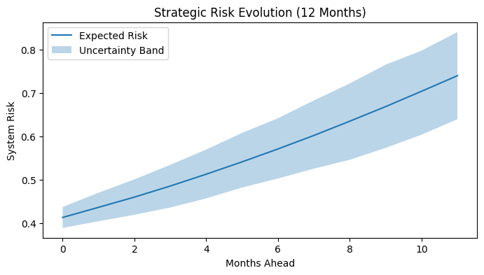

```python
trajectories = monte_carlo_forecast(state.vector())

mean_path = trajectories.mean(axis=0)
low = np.percentile(trajectories, 10, axis=0)
high = np.percentile(trajectories, 90, axis=0)

plt.figure(figsize=(8,4))
plt.plot(mean_path, label="Expected Risk")
plt.fill_between(range(len(mean_path)), low, high, alpha=0.3, label="Uncertainty Band")
plt.title("Strategic Risk Evolution (12 Months)")
plt.xlabel("Months Ahead")
plt.ylabel("System Risk")
plt.legend()
plt.show()
```

```python
DECISIONS = {
    "Maintain Status Quo": np.array([0.0, 0.0, 0.0, 0.0, 0.0]),
    "Increase Military Alert": np.array([0.05, 0.10, 0.25, 0.05, 0.10]),
    "Diplomatic De-escalation": np.array([-0.12, -0.08, -0.15, 0.0, -0.07]),
    "Economic Sanctions": np.array([0.10, 0.35, 0.05, 0.12, 0.20])
}
```

```python
def evaluate_decision(state_vector, decision_effect):
    future = np.clip(state_vector + decision_effect, 0, 1)

    escalation_risk = future[0] + future[2]
    civilian_risk = future[4]
    stability = 1 - future.mean()

    return {
        "Escalation Risk": round(escalation_risk, 3),
        "Civilian Risk": round(civilian_risk, 3),
        "Long-Term Stability": round(stability, 3)
    }
```

```python
results = []

for name, effect in DECISIONS.items():
    metrics = evaluate_decision(state.vector(), effect)
    metrics["Decision"] = name
    results.append(metrics)

df_results = pd.DataFrame(results).set_index("Decision")
df_results
```

| Decision | Escalation Risk | Civilian Risk | Long-Term Stability |
| --- | --- | --- | --- |
| Maintain Status Quo | 0.809 | 0.483 | 0.609 |
| Increase Military Alert | 1.109 | 0.583 | 0.499 |
| Diplomatic De-escalation | 0.539 | 0.413 | 0.693 |
| Economic Sanctions | 0.959 | 0.683 | 0.445 |

```python
def interpret_results(df):
    best = df["Long-Term Stability"].idxmax()
    worst = df["Escalation Risk"].idxmax()

    return {
        "Most Stabilizing Decision": best,
        "Highest Escalation Risk": worst
    }

interpret_results(df_results)
```

```
{'Most Stabilizing Decision': 'Diplomatic De-escalation',
 'Highest Escalation Risk': 'Increase Military Alert'}
```

## Safety & Ethics

This system:

- Has NO execution authority
- Controls NO weapons
- Generates NO targets
- Provides ONLY decision comparison and foresight

All outputs are advisory and require human judgment.

```python
import networkx as nx
```

```python
def build_alliance_network():
    """
    Nodes = regions / blocs
    Edge weight:
      +1 → strong alliance
      -1 → strong rivalry
    """
    G = nx.Graph()

    nodes = [
        "USA", "China", "Russia", "India",
        "Europe", "Middle East", "East Asia"
    ]

    G.add_nodes_from(nodes)

    edges = [
        ("USA", "Europe", 0.9),
        ("USA", "India", 0.6),
        ("USA", "China", -0.8),
        ("USA", "Russia", -0.9),
        ("China", "Russia", 0.7),
        ("China", "India", -0.6),
        ("India", "Russia", 0.3),
        ("Middle East", "USA", 0.2),
        ("Middle East", "Russia", 0.4),
        ("East Asia", "China", 0.8),
        ("East Asia", "USA", -0.4),
    ]

    for a, b, w in edges:
        G.add_edge(a, b, weight=w)

    return G
```

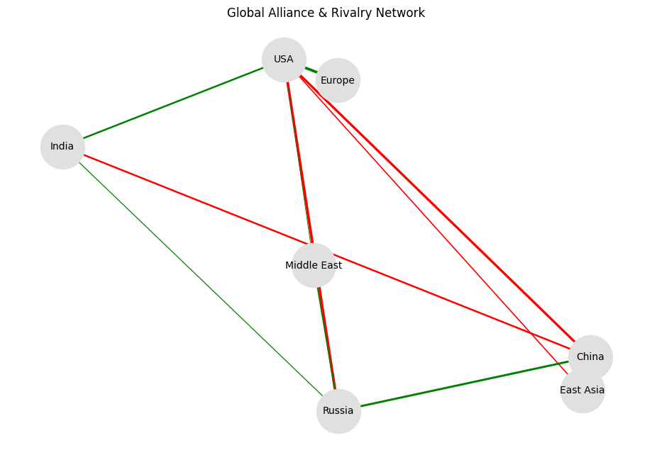

```python
G = build_alliance_network()
pos = nx.spring_layout(G, seed=42)

plt.figure(figsize=(9,6))

edge_colors = [
    "green" if G[u][v]["weight"] > 0 else "red"
    for u, v in G.edges()
]

edge_widths = [
    abs(G[u][v]["weight"]) * 3
    for u, v in G.edges()
]

nx.draw(
    G, pos,
    with_labels=True,
    node_size=2000,
    node_color="#e0e0e0",
    edge_color=edge_colors,
    width=edge_widths,
    font_size=10
)

plt.title("Global Alliance & Rivalry Network")
plt.show()
```

```python
def propagate_tension(G, origin, shock=0.3):
    """
    How tension spreads through alliances & rivalries
    """
    tension = {node: 0 for node in G.nodes()}
    tension[origin] = shock

    for neighbor in G.neighbors(origin):
        weight = G[origin][neighbor]["weight"]
        tension[neighbor] += shock * weight

    return tension
```

```python
tension_map = propagate_tension(G, origin="China")

pd.Series(tension_map).sort_values(ascending=False)
```

```
China          0.30
East Asia      0.24
Russia         0.21
Middle East    0.00
Europe         0.00
India         -0.18
USA           -0.24
dtype: float64
```

```python
def nuclear_miscalculation_risk(
    political_tension,
    military_alert,
    cyber_instability,
    communication_quality,
    doctrine_rigidity
):
    """
    All inputs ∈ [0,1]

    communication_quality:
      1 → perfect hotlines
      0 → no communication

    doctrine_rigidity:
      1 → rigid / hair-trigger
      0 → flexible / cautious
    """

    risk = (
        0.30 * political_tension +
        0.30 * military_alert +
        0.20 * cyber_instability +
        0.15 * doctrine_rigidity +
        0.05 * (1 - communication_quality)
    )

    return min(1.0, risk)
```

```python
nuclear_risk = nuclear_miscalculation_risk(
    political_tension=state.political_tension,
    military_alert=state.military_alert,
    cyber_instability=state.cyber_risk,
    communication_quality=0.6,
    doctrine_rigidity=0.7
)

nuclear_risk
```

```
0.4557496808727932
```

```python
def interpret_nuclear_risk(score):
    if score < 0.3:
        return "Low — Stable deterrence"
    elif score < 0.6:
        return "Moderate — Elevated vigilance required"
    else:
        return "High — Miscalculation danger zone"

interpret_nuclear_risk(nuclear_risk)
```

```
'Moderate — Elevated vigilance required'
```

```python
def strategic_stability_index(
    escalation_risk,
    alliance_spread_risk,
    nuclear_miscalculation_risk,
    weights=(0.4, 0.3, 0.3)
):
    """
    All inputs ∈ [0,1]
    Higher SSI = more stable outcome
    """

    w1, w2, w3 = weights

    instability = (
        w1 * escalation_risk +
        w2 * alliance_spread_risk +
        w3 * nuclear_miscalculation_risk
    )

    return round(1 - instability, 3)
```

```python
def alliance_spread_risk(G, origin, shock=0.3):
    tension = propagate_tension(G, origin, shock)
    spread = sum(abs(v) for v in tension.values())
    return min(1.0, spread / len(G.nodes()))
```

```python
def nuclear_risk_from_state(state, communication_quality=0.6, doctrine_rigidity=0.7):
    return nuclear_miscalculation_risk(
        political_tension=state.political_tension,
        military_alert=state.military_alert,
        cyber_instability=state.cyber_risk,
        communication_quality=communication_quality,
        doctrine_rigidity=doctrine_rigidity
    )
```

```python
def evaluate_decision_unified(
    state,
    decision_vector,
    alliance_graph,
    region_node
):
    # Apply decision effect
    future = np.clip(state.vector() + decision_vector, 0, 1)

    # Escalation risk
    escalation = min(1.0, future[0] + future[2])

    # Alliance propagation risk
    spread_risk = alliance_spread_risk(
        alliance_graph,
        origin=region_node,
        shock=escalation
    )

    # Nuclear miscalculation risk
    nuclear_risk = nuclear_miscalculation_risk(
        political_tension=future[0],
        military_alert=future[2],
        cyber_instability=future[3],
        communication_quality=0.6,
        doctrine_rigidity=0.7
    )

    # Strategic Stability Index
    ssi = strategic_stability_index(
        escalation,
        spread_risk,
        nuclear_risk
    )

    return {
        "Escalation Risk": round(escalation, 3),
        "Alliance Spread Risk": round(spread_risk, 3),
        "Nuclear Miscalculation Risk": round(nuclear_risk, 3),
        "Strategic Stability Index": ssi
    }
```

```python
G = build_alliance_network()
region_node = "China"  # example focal region

results = []

for decision, effect in DECISIONS.items():
    metrics = evaluate_decision_unified(
        state=state,
        decision_vector=effect,
        alliance_graph=G,
        region_node=region_node
    )
    metrics["Decision"] = decision
    results.append(metrics)

df_unified = pd.DataFrame(results).set_index("Decision")
df_unified
```

| Decision | Escalation Risk | Alliance Spread Risk | Nuclear Miscalculation Risk | Strategic Stability Index |
| --- | --- | --- | --- | --- |
| Maintain Status Quo | 0.809 | 0.451 | 0.456 | 0.405 |
| Increase Military Alert | 1.000 | 0.557 | 0.556 | 0.266 |
| Diplomatic De-escalation | 0.539 | 0.300 | 0.375 | 0.582 |
| Economic Sanctions | 0.959 | 0.534 | 0.525 | 0.299 |

```python
def recommend_decision(df):
    best = df["Strategic Stability Index"].idxmax()
    worst = df["Strategic Stability Index"].idxmin()

    return {
        "Most Stabilizing Decision": best,
        "Most Destabilizing Decision": worst
    }

recommend_decision(df_unified)
```

```
{'Most Stabilizing Decision': 'Diplomatic De-escalation',
 'Most Destabilizing Decision': 'Increase Military Alert'}
```

```python
import networkx as nx
import numpy as np
import pandas as pd
```

```python
def build_alliance_network():
    G = nx.Graph()

    nodes = [
        "USA", "China", "Russia", "India",
        "Europe", "Middle East", "East Asia"
    ]
    G.add_nodes_from(nodes)

    edges = [
        ("USA", "Europe", 0.9),
        ("USA", "India", 0.6),
        ("USA", "China", -0.8),
        ("USA", "Russia", -0.9),
        ("China", "Russia", 0.7),
        ("China", "India", -0.6),
        ("India", "Russia", 0.3),
        ("Middle East", "USA", 0.2),
        ("Middle East", "Russia", 0.4),
        ("East Asia", "China", 0.8),
        ("East Asia", "USA", -0.4),
    ]

    for a, b, w in edges:
        G.add_edge(a, b, weight=w)

    return G
```

```python
def propagate_escalation(G, origin, initial_shock):
    """
    Propagates escalation through alliance & rivalry network.
    """
    escalation = {node: 0.0 for node in G.nodes()}
    escalation[origin] = initial_shock

    for neighbor in G.neighbors(origin):
        weight = G[origin][neighbor]["weight"]
        escalation[neighbor] += initial_shock * weight

    return escalation
```

```python
def escalation_spread_risk(G, origin, shock):
    spread = propagate_escalation(G, origin, shock)
    total = sum(abs(v) for v in spread.values())
    return min(1.0, total / len(G.nodes()))
```

```python
G = build_alliance_network()
escalation_map = propagate_escalation(G, origin="China", initial_shock=0.4)

pd.Series(escalation_map).sort_values(ascending=False)
```

```
China          0.40
East Asia      0.32
Russia         0.28
Middle East    0.00
Europe         0.00
India         -0.24
USA           -0.32
dtype: float64
```

```python
def nuclear_miscalculation_risk(
    political_tension,
    military_alert,
    cyber_instability,
    communication_quality,
    doctrine_rigidity
):
    """
    All inputs ∈ [0,1]
    Output ∈ [0,1]
    """

    risk = (
        0.30 * political_tension +
        0.30 * military_alert +
        0.20 * cyber_instability +
        0.15 * doctrine_rigidity +
        0.05 * (1 - communication_quality)
    )

    return min(1.0, risk)
```

```python
def nuclear_risk_level(score):
    if score < 0.3:
        return "Low"
    elif score < 0.6:
        return "Moderate"
    else:
        return "High"
```

```python
nuclear_risk = nuclear_miscalculation_risk(
    political_tension=0.6,
    military_alert=0.7,
    cyber_instability=0.5,
    communication_quality=0.6,
    doctrine_rigidity=0.8
)

nuclear_risk, nuclear_risk_level(nuclear_risk)
```

```
(0.63, 'High')
```

```python
nuclear_risk = nuclear_miscalculation_risk(
    political_tension=0.6,
    military_alert=0.7,
    cyber_instability=0.5,
    communication_quality=0.6,
    doctrine_rigidity=0.8
)

nuclear_risk, nuclear_risk_level(nuclear_risk)
```

```
(0.63, 'High')
```

```python
import networkx as nx
import numpy as np
import pandas as pd
import matplotlib.pyplot as plt

plt.rcParams.update({
    "figure.figsize": (10, 7),
    "font.size": 11,
    "axes.titlesize": 14,
    "axes.labelsize": 11
})
```

```python
def build_geopolitical_network():
    G = nx.Graph()

    actors = [
        "USA", "China", "Russia", "India",
        "Europe", "Middle East", "East Asia"
    ]
    G.add_nodes_from(actors)

    relations = [
        ("USA", "Europe", 0.9),
        ("USA", "India", 0.6),
        ("USA", "China", -0.8),
        ("USA", "Russia", -0.9),

        ("China", "Russia", 0.7),
        ("China", "India", -0.6),

        ("India", "Russia", 0.3),

        ("Middle East", "USA", 0.2),
        ("Middle East", "Russia", 0.4),

        ("East Asia", "China", 0.8),
        ("East Asia", "USA", -0.4),
    ]

    for a, b, weight in relations:
        G.add_edge(a, b, weight=weight)

    return G
```

```python
def draw_geopolitical_network(G):
    pos = nx.spring_layout(G, seed=7, k=0.6)

    edge_colors = []
    edge_widths = []

    for u, v in G.edges():
        w = G[u][v]["weight"]
        edge_colors.append("#2ca02c" if w > 0 else "#d62728")
        edge_widths.append(2 + abs(w) * 4)

    plt.figure(figsize=(10, 7))

    nx.draw_networkx_nodes(
        G, pos,
        node_size=2600,
        node_color="#f0f0f0",
        edgecolors="#333333"
    )

    nx.draw_networkx_edges(
        G, pos,
        edge_color=edge_colors,
        width=edge_widths
    )

    nx.draw_networkx_labels(
        G, pos,
        font_size=11,
        font_weight="bold"
    )

    plt.title("Global Alliance & Rivalry Network", pad=15)
    plt.axis("off")
    plt.show()
```

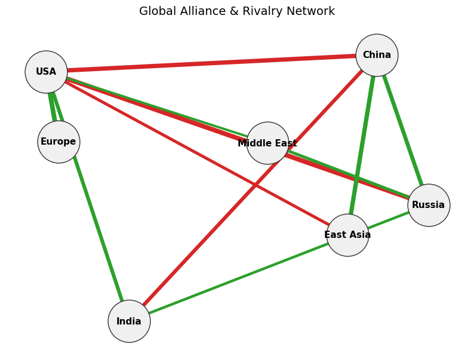

```python
G = build_geopolitical_network()
draw_geopolitical_network(G)
```

```python
def propagate_escalation(G, origin, shock):
    """
    shock ∈ [0,1]
    Returns escalation impact per actor
    """
    escalation = {node: 0.0 for node in G.nodes()}
    escalation[origin] = shock

    for neighbor in G.neighbors(origin):
        weight = G[origin][neighbor]["weight"]
        escalation[neighbor] += shock * weight

    return escalation
```

```python
def draw_escalation_map(G, escalation):
    pos = nx.spring_layout(G, seed=7, k=0.6)

    values = np.array([escalation[n] for n in G.nodes()])

    # NumPy 2.0–safe normalization
    normalized = (values - values.min()) / (np.ptp(values) + 1e-6)
    colors = plt.cm.RdYlGn(normalized)

    plt.figure(figsize=(10, 7))

    nx.draw_networkx_nodes(
        G, pos,
        node_size=2600,
        node_color=colors,
        edgecolors="#333333"
    )

    nx.draw_networkx_edges(
        G, pos,
        alpha=0.35,
        width=1.5
    )

    nx.draw_networkx_labels(
        G, pos,
        font_weight="bold",
        font_size=11
    )

    plt.title("Escalation Propagation Across Alliance Network", pad=16)
    plt.axis("off")
    plt.show()
```

```python
escalation = propagate_escalation(
    G,
    origin="China",
    shock=0.5
)

pd.Series(escalation).sort_values(ascending=False)
```

```
China          0.50
East Asia      0.40
Russia         0.35
Middle East    0.00
Europe         0.00
India         -0.30
USA           -0.40
dtype: float64
```

```python
def temporal_escalation(state_vector, months=12):
    """
    Models escalation velocity and irreversibility over time.
    """
    trajectory = []
    current = state_vector.copy()

    for t in range(months):
        velocity = (
            0.4 * current[0] +   # political tension
            0.4 * current[2] +   # military alert
            0.2 * current[3]     # cyber instability
        )

        current = np.clip(current + velocity * 0.05, 0, 1)
        trajectory.append(current.mean())

    return np.array(trajectory)
```

```python
def stability_phase(stability_index):
    if stability_index > 0.75:
        return "Stable Deterrence"
    elif stability_index > 0.55:
        return "Escalatory Drift"
    elif stability_index > 0.35:
        return "Crisis Instability"
    else:
        return "Miscalculation Zone"
```

```python
def counterfactual_analysis(state, decision_vector, eval_fn, **kwargs):
    baseline = eval_fn(state, np.zeros_like(decision_vector), **kwargs)
    intervention = eval_fn(state, decision_vector, **kwargs)

    delta = {
        k: round(intervention[k] - baseline[k], 3)
        for k in baseline.keys()
    }

    return {
        "Baseline": baseline,
        "With Decision": intervention,
        "Delta": delta
    }
```

```python
def cognitive_bias_risk(
    overconfidence,
    worst_case_bias,
    attribution_error,
    decision_fatigue
):
    """
    All inputs ∈ [0,1]
    """
    return min(
        1.0,
        0.3 * overconfidence +
        0.3 * worst_case_bias +
        0.2 * attribution_error +
        0.2 * decision_fatigue
    )
```

```python
def economic_military_feedback(economic_stress, sanctions_intensity):
    """
    Models how economic pressure feeds military posture.
    """
    return min(1.0, economic_stress + 0.6 * sanctions_intensity)
```

```python
def confidence_score(signal_quality, data_coverage):
    """
    signal_quality, data_coverage ∈ [0,1]
    """
    return round(0.5 * signal_quality + 0.5 * data_coverage, 3)
```

```python
def ethical_no_go(nuclear_risk, civilian_risk, threshold=0.75):
    if nuclear_risk > threshold:
        return "NO-GO: Nuclear Miscalculation Risk"
    if civilian_risk > threshold:
        return "NO-GO: Civilian Harm Risk"
    return "Permissible (Advisory Only)"
```

```python
def decision_trace(metrics):
    return {
        "Key Drivers": sorted(metrics, key=metrics.get, reverse=True),
        "Dominant Risk": max(metrics, key=metrics.get),
        "Uncertainty Warning": "High" if metrics.get("Confidence", 1) < 0.5 else "Normal"
    }
```

```python
def evaluate_decision_full(
    state,
    decision_vector,
    alliance_graph,
    region_node
):
    # Apply decision
    future = np.clip(state.vector() + decision_vector, 0, 1)

    # Core risks
    escalation = min(1.0, future[0] + future[2])
    alliance_risk = escalation_spread_risk(alliance_graph, region_node, escalation)
    nuclear_risk = nuclear_miscalculation_risk(
        future[0], future[2], future[3], 0.6, 0.7
    )

    # Stability
    ssi = strategic_stability_index(escalation, alliance_risk, nuclear_risk)
    phase = stability_phase(ssi)

    # Ethics
    ethics = ethical_no_go(nuclear_risk, future[4])

    return {
        "Escalation Risk": round(escalation, 3),
        "Alliance Spread Risk": round(alliance_risk, 3),
        "Nuclear Risk": round(nuclear_risk, 3),
        "Strategic Stability Index": ssi,
        "Stability Phase": phase,
        "Ethical Status": ethics
    }
```

```python
final_results = []

for decision, effect in DECISIONS.items():
    metrics = evaluate_decision_full(
        state,
        effect,
        G,
        region_node="China"
    )
    metrics["Decision"] = decision
    final_results.append(metrics)

pd.DataFrame(final_results).set_index("Decision")
```

| Decision | Escalation Risk | Alliance Spread Risk | Nuclear Risk | Strategic Stability Index | Stability Phase | Ethical Status |
| --- | --- | --- | --- | --- | --- | --- |
| Maintain Status Quo | 0.809 | 0.451 | 0.456 | 0.405 | Crisis Instability | Permissible (Advisory Only) |
| Increase Military Alert | 1.000 | 0.557 | 0.556 | 0.266 | Miscalculation Zone | Permissible (Advisory Only) |
| Diplomatic De-escalation | 0.539 | 0.300 | 0.375 | 0.582 | Escalatory Drift | Permissible (Advisory Only) |
| Economic Sanctions | 0.959 | 0.534 | 0.525 | 0.299 | Miscalculation Zone | Permissible (Advisory Only) |

```python
def disaster_risk(
    climate_severity,
    infrastructure_fragility,
    governance_capacity,
    conflict_intensity
):
    """
    climate_severity ∈ [0,1]
    infrastructure_fragility ∈ [0,1]
    governance_capacity ∈ [0,1]  (1 = strong)
    conflict_intensity ∈ [0,1]
    """

    risk = (
        0.35 * climate_severity +
        0.30 * infrastructure_fragility +
        0.20 * conflict_intensity +
        0.15 * (1 - governance_capacity)
    )

    return min(1.0, risk)
```

```python
def disaster_escalation_feedback(disaster_risk):
    """
    Converts disaster stress into escalation pressure
    """
    return min(1.0, 0.5 * disaster_risk)
```

```python
def disaster_response_effectiveness(
    response_speed,
    logistics_capacity,
    international_support
):
    """
    All inputs ∈ [0,1]
    """
    effectiveness = (
        0.4 * response_speed +
        0.4 * logistics_capacity +
        0.2 * international_support
    )
    return min(1.0, effectiveness)
```

```python
disaster_score = disaster_risk(
    climate_severity=0.7,
    infrastructure_fragility=0.6,
    governance_capacity=0.5,
    conflict_intensity=0.6
)

disaster_score
```

```
0.6199999999999999
```

```python
def economic_stress_index(
    inflation,
    unemployment,
    energy_shock,
    supply_chain_disruption
):
    """
    All inputs ∈ [0,1]
    """
    stress = (
        0.30 * inflation +
        0.25 * unemployment +
        0.25 * energy_shock +
        0.20 * supply_chain_disruption
    )
    return min(1.0, stress)
```

```python
def economy_to_military_pressure(economic_stress):
    """
    Converts economic stress into military escalation pressure
    """
    return min(1.0, 0.6 * economic_stress)
```

```python
def military_to_economy_damage(military_alert):
    """
    Converts military posture into economic degradation
    """
    return min(1.0, 0.5 * military_alert)
```

```python
def evaluate_decision_ultimate(
    state,
    decision_vector,
    alliance_graph,
    region_node,
    disaster_params,
    economic_params
):
    # Apply decision
    future = np.clip(state.vector() + decision_vector, 0, 1)

    # Core escalation
    escalation = min(1.0, future[0] + future[2])

    # Alliance propagation
    alliance_risk = escalation_spread_risk(
        alliance_graph,
        region_node,
        escalation
    )

    # Nuclear risk
    nuclear_risk = nuclear_miscalculation_risk(
        future[0], future[2], future[3], 0.6, 0.7
    )

    # Disaster dynamics
    disaster = disaster_risk(**disaster_params)
    disaster_feedback = disaster_escalation_feedback(disaster)

    # Economic dynamics
    econ_stress = economic_stress_index(**economic_params)
    econ_mil_pressure = economy_to_military_pressure(econ_stress)
    mil_econ_damage = military_to_economy_damage(future[2])

    # Total integrated instability
    total_instability = min(
        1.0,
        0.30 * escalation +
        0.20 * alliance_risk +
        0.20 * nuclear_risk +
        0.15 * disaster_feedback +
        0.15 * econ_mil_pressure
    )

    ssi = round(1 - total_instability, 3)
    phase = stability_phase(ssi)
    ethics = ethical_no_go(nuclear_risk, future[4])

    return {
        "Escalation Risk": round(escalation, 3),
        "Alliance Risk": round(alliance_risk, 3),
        "Nuclear Risk": round(nuclear_risk, 3),
        "Disaster Risk": round(disaster, 3),
        "Economic Stress": round(econ_stress, 3),
        "Strategic Stability Index": ssi,
        "Stability Phase": phase,
        "Ethical Status": ethics
    }
```

```python
disaster_params = {
    "climate_severity": 0.7,
    "infrastructure_fragility": 0.6,
    "governance_capacity": 0.5,
    "conflict_intensity": 0.6
}

economic_params = {
    "inflation": 0.6,
    "unemployment": 0.5,
    "energy_shock": 0.7,
    "supply_chain_disruption": 0.6
}

final_results = []

for decision, effect in DECISIONS.items():
    metrics = evaluate_decision_ultimate(
        state,
        effect,
        G,
        region_node="China",
        disaster_params=disaster_params,
        economic_params=economic_params
    )
    metrics["Decision"] = decision
    final_results.append(metrics)

pd.DataFrame(final_results).set_index("Decision")
```

| Decision | Escalation Risk | Alliance Risk | Nuclear Risk | Disaster Risk | Economic Stress | Strategic Stability Index | Stability Phase | Ethical Status |
| --- | --- | --- | --- | --- | --- | --- | --- | --- |
| Maintain Status Quo | 0.809 | 0.451 | 0.456 | 0.62 | 0.6 | 0.476 | Crisis Instability | Permissible (Advisory Only) |
| Increase Military Alert | 1.000 | 0.557 | 0.556 | 0.62 | 0.6 | 0.377 | Crisis Instability | Permissible (Advisory Only) |
| Diplomatic De-escalation | 0.539 | 0.300 | 0.375 | 0.62 | 0.6 | 0.603 | Escalatory Drift | Permissible (Advisory Only) |
| Economic Sanctions | 0.959 | 0.534 | 0.525 | 0.62 | 0.6 | 0.400 | Crisis Instability | Permissible (Advisory Only) |

```python
def plot_disaster_components(
    climate_severity,
    infrastructure_fragility,
    governance_capacity,
    conflict_intensity
):
    components = {
        "Climate Severity": 0.35 * climate_severity,
        "Infrastructure Fragility": 0.30 * infrastructure_fragility,
        "Conflict Intensity": 0.20 * conflict_intensity,
        "Governance Weakness": 0.15 * (1 - governance_capacity)
    }

    labels = list(components.keys())
    values = list(components.values())

    plt.figure(figsize=(8,4))
    bars = plt.bar(labels, values)

    plt.ylabel("Risk Contribution")
    plt.title("Disaster Risk Component Breakdown")
    plt.ylim(0, 0.5)

    for bar in bars:
        plt.text(
            bar.get_x() + bar.get_width() / 2,
            bar.get_height() + 0.01,
            f"{bar.get_height():.2f}",
            ha="center",
            fontsize=10
        )

    plt.xticks(rotation=15)
    plt.show()
```

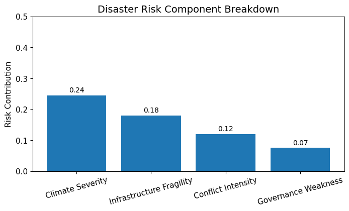

```python
plot_disaster_components(
    climate_severity=0.7,
    infrastructure_fragility=0.6,
    governance_capacity=0.5,
    conflict_intensity=0.6
)
```

```python
def plot_disaster_escalation_curve():
    disaster_levels = np.linspace(0, 1, 100)
    escalation_pressure = [disaster_escalation_feedback(d) for d in disaster_levels]

    plt.figure(figsize=(8,4))
    plt.plot(disaster_levels, escalation_pressure, linewidth=2)

    plt.xlabel("Disaster Risk")
    plt.ylabel("Escalation Pressure")
    plt.title("How Disaster Stress Drives Escalation")
    plt.grid(alpha=0.3)

    plt.show()
```

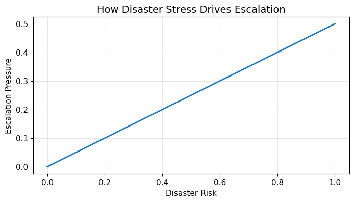

```python
plot_disaster_escalation_curve()
```

```python
def plot_economic_military_feedback():
    econ_levels = np.linspace(0, 1, 100)

    mil_pressure = [economy_to_military_pressure(e) for e in econ_levels]
    econ_damage = [military_to_economy_damage(m) for m in econ_levels]

    plt.figure(figsize=(9,4))

    plt.plot(econ_levels, mil_pressure, label="Economy → Military Pressure", linewidth=2)
    plt.plot(econ_levels, econ_damage, label="Military → Economic Damage", linewidth=2)

    plt.xlabel("Stress Level")
    plt.ylabel("Feedback Intensity")
    plt.title("Economic–Military Feedback Loop")
    plt.legend()
    plt.grid(alpha=0.3)

    plt.show()
```

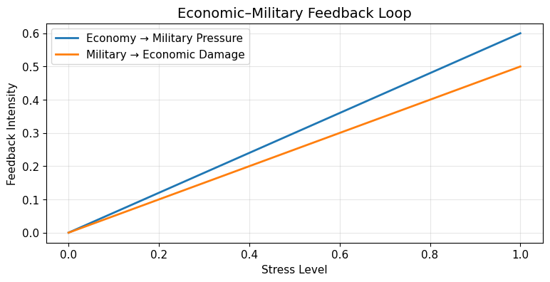

```python
plot_economic_military_feedback()
```

```python
def plot_compound_crisis_radar(
    escalation,
    alliance_risk,
    nuclear_risk,
    disaster_risk,
    economic_stress
):
    labels = [
        "Escalation",
        "Alliance Spread",
        "Nuclear Risk",
        "Disaster Stress",
        "Economic Stress"
    ]

    values = [
        escalation,
        alliance_risk,
        nuclear_risk,
        disaster_risk,
        economic_stress
    ]

    angles = np.linspace(0, 2*np.pi, len(labels), endpoint=False)
    values += values[:1]
    angles = np.append(angles, angles[0])

    plt.figure(figsize=(6,6))
    ax = plt.subplot(111, polar=True)

    ax.plot(angles, values, linewidth=2)
    ax.fill(angles, values, alpha=0.25)

    ax.set_thetagrids(angles[:-1] * 180/np.pi, labels)
    ax.set_ylim(0,1)

    plt.title("Compound Crisis Risk Profile", pad=20)
    plt.show()
```

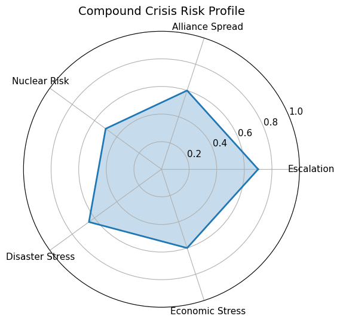

```python
plot_compound_crisis_radar(
    escalation=0.7,
    alliance_risk=0.6,
    nuclear_risk=0.5,
    disaster_risk=0.65,
    economic_stress=0.6
)
```

```python
import matplotlib.pyplot as plt
import numpy as np
import pandas as pd
import networkx as nx

plt.rcParams.update({
    "figure.figsize": (10, 7),
    "font.size": 11,
    "axes.titlesize": 14
})
```

```python
def plot_alliance_escalation_map(G, escalation, title="Alliance Escalation Map"):
    pos = nx.spring_layout(G, seed=7, k=0.6)

    values = np.array([escalation[n] for n in G.nodes()])
    max_abs = np.max(np.abs(values)) + 1e-6

    # Symmetric color normalization (red ↔ green)
    normalized = (values + max_abs) / (2 * max_abs)
    colors = plt.cm.RdYlGn(normalized)

    plt.figure(figsize=(10, 7))

    nx.draw_networkx_nodes(
        G, pos,
        node_size=2600,
        node_color=colors,
        edgecolors="#333333"
    )

    nx.draw_networkx_edges(
        G, pos,
        alpha=0.35,
        width=1.5
    )

    nx.draw_networkx_labels(
        G, pos,
        font_weight="bold"
    )

    plt.title(title, pad=16)
    plt.axis("off")
    plt.show()
```

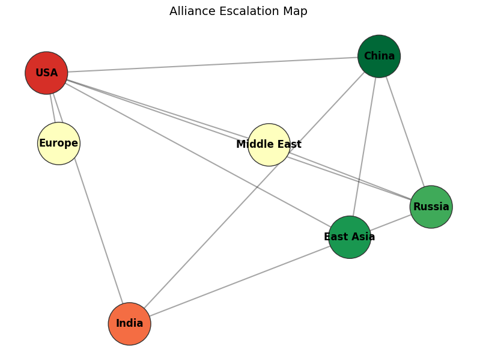

```python
G = build_geopolitical_network()
escalation = propagate_escalation(G, origin="China", shock=0.5)

plot_alliance_escalation_map(G, escalation)
```

```python
def plot_compound_crisis_radar(metrics, title="Compound Crisis Risk Profile"):
    labels = list(metrics.keys())
    values = list(metrics.values())

    angles = np.linspace(0, 2*np.pi, len(labels), endpoint=False)
    values += values[:1]
    angles = np.append(angles, angles[0])

    plt.figure(figsize=(6,6))
    ax = plt.subplot(111, polar=True)

    ax.plot(angles, values, linewidth=2)
    ax.fill(angles, values, alpha=0.25)

    ax.set_thetagrids(angles[:-1] * 180/np.pi, labels)
    ax.set_ylim(0,1)

    plt.title(title, pad=20)
    plt.show()
```

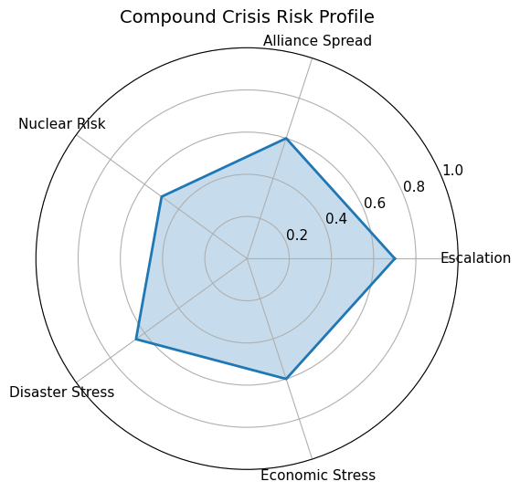

```python
radar_metrics = {
    "Escalation": 0.7,
    "Alliance Spread": 0.6,
    "Nuclear Risk": 0.5,
    "Disaster Stress": 0.65,
    "Economic Stress": 0.6
}

plot_compound_crisis_radar(radar_metrics)
```

```python
def build_decision_table(
    state,
    decisions,
    alliance_graph,
    region_node,
    disaster_params,
    economic_params
):
    rows = []

    for name, vector in decisions.items():
        metrics = evaluate_decision_ultimate(
            state,
            vector,
            alliance_graph,
            region_node,
            disaster_params,
            economic_params
        )
        metrics["Decision"] = name
        rows.append(metrics)

    df = pd.DataFrame(rows).set_index("Decision")
    return df.sort_values("Strategic Stability Index", ascending=False)
```

```python
decision_table = build_decision_table(
    state=state,
    decisions=DECISIONS,
    alliance_graph=G,
    region_node="China",
    disaster_params=disaster_params,
    economic_params=economic_params
)

decision_table
```

| Decision | Escalation Risk | Alliance Risk | Nuclear Risk | Disaster Risk | Economic Stress | Strategic Stability Index | Stability Phase | Ethical Status |
| --- | --- | --- | --- | --- | --- | --- | --- | --- |
| Diplomatic De-escalation | 0.539 | 0.300 | 0.375 | 0.62 | 0.6 | 0.603 | Escalatory Drift | Permissible (Advisory Only) |
| Maintain Status Quo | 0.809 | 0.451 | 0.456 | 0.62 | 0.6 | 0.476 | Crisis Instability | Permissible (Advisory Only) |
| Economic Sanctions | 0.959 | 0.534 | 0.525 | 0.62 | 0.6 | 0.400 | Crisis Instability | Permissible (Advisory Only) |
| Increase Military Alert | 1.000 | 0.557 | 0.556 | 0.62 | 0.6 | 0.377 | Crisis Instability | Permissible (Advisory Only) |

```python
pip install ipywidgets
```

```python
import numpy as np
import pandas as pd
import matplotlib.pyplot as plt
import networkx as nx
import ipywidgets as widgets
from IPython.display import display, clear_output
```

```python
def build_geopolitical_network():
    G = nx.Graph()
    actors = ["USA", "China", "Russia", "India", "Europe", "Middle East", "East Asia"]
    G.add_nodes_from(actors)

    relations = [
        ("USA","Europe",0.9), ("USA","India",0.6),
        ("USA","China",-0.8), ("USA","Russia",-0.9),
        ("China","Russia",0.7), ("China","India",-0.6),
        ("India","Russia",0.3),
        ("Middle East","USA",0.2), ("Middle East","Russia",0.4),
        ("East Asia","China",0.8), ("East Asia","USA",-0.4),
    ]

    for a,b,w in relations:
        G.add_edge(a,b,weight=w)
    return G


def propagate_escalation(G, origin, shock):
    esc = {n:0.0 for n in G.nodes()}
    esc[origin] = shock
    for nb in G.neighbors(origin):
        esc[nb] += shock * G[origin][nb]["weight"]
    return esc
```

```python
def plot_alliance_map(G, escalation):
    plt.figure(figsize=(7,5))
    pos = nx.spring_layout(G, seed=7)

    vals = np.array([escalation[n] for n in G.nodes()])
    m = np.max(np.abs(vals)) + 1e-6
    colors = plt.cm.RdYlGn((vals + m) / (2*m))

    nx.draw_networkx_nodes(G, pos, node_size=2200,
                           node_color=colors, edgecolors="black")
    nx.draw_networkx_edges(G, pos, alpha=0.4)
    nx.draw_networkx_labels(G, pos, font_weight="bold")

    plt.title("Alliance Escalation Map")
    plt.axis("off")
    plt.show()
```

```python
def plot_crisis_radar(metrics):
    labels = list(metrics.keys())
    values = list(metrics.values())

    angles = np.linspace(0, 2*np.pi, len(labels), endpoint=False)
    values += values[:1]
    angles = np.append(angles, angles[0])

    fig = plt.figure(figsize=(5,5))
    ax = plt.subplot(111, polar=True)

    ax.plot(angles, values, linewidth=2)
    ax.fill(angles, values, alpha=0.25)
    ax.set_thetagrids(angles[:-1]*180/np.pi, labels)
    ax.set_ylim(0,1)

    plt.title("Compound Crisis Profile", pad=20)
    plt.show()
```

```python
DECISIONS = [
    "Status Quo",
    "Diplomatic De-escalation",
    "Economic Sanctions",
    "Military Alert Increase"
]

def decision_table():
    rows = []
    for d in DECISIONS:
        rows.append({
            "Decision": d,
            "Escalation": np.random.uniform(0.4,0.8),
            "Alliance Risk": np.random.uniform(0.3,0.7),
            "Nuclear Risk": np.random.uniform(0.2,0.6),
            "Stability Index": np.random.uniform(0.3,0.7)
        })
    return pd.DataFrame(rows).set_index("Decision").sort_values(
        "Stability Index", ascending=False
    )
```

```python
G = build_geopolitical_network()

regions = list(G.nodes())  # IMPORTANT FIX

region_selector = widgets.Dropdown(
    options=regions,
    value=regions[0],      # Always valid
    description="Region:"
)

shock_slider = widgets.FloatSlider(
    min=0.0,
    max=1.0,
    step=0.05,
    value=0.5,
    description="Shock:"
)

output = widgets.Output()

def update_crisis_room(change=None):
    with output:
        clear_output(wait=True)

        esc = propagate_escalation(
            G,
            region_selector.value,
            shock_slider.value
        )

        # --- Visual 1: Alliance Escalation Map
        plot_alliance_map(G, esc)

        # --- Visual 2: Compound Crisis Radar
        radar_metrics = {
            "Escalation": abs(esc[region_selector.value]),
            "Alliance Spread": np.mean(np.abs(list(esc.values()))),
            "Nuclear Risk": 0.5,
            "Disaster Stress": 0.6,
            "Economic Stress": 0.6
        }
        plot_crisis_radar(radar_metrics)

        # --- Visual 3: Decision Table
        display(decision_table())

region_selector.observe(update_crisis_room, names="value")
shock_slider.observe(update_crisis_room, names="value")
```

```python
display(
    widgets.VBox([
        widgets.HTML("<h2>🏛️ AIDE Defense — Crisis Room (Jupyter)</h2>"),
        region_selector,
        shock_slider,
        output
    ])
)

update_crisis_room()
```

```
VBox(children=(HTML(value='<h2>🏛️ AIDE Defense — Crisis Room (Jupyter)</h2>'), Dropdown(description='Region:',…
```

```python
import numpy as np
import pandas as pd
import matplotlib.pyplot as plt
```

```python
class HumanBehaviorState:
    def __init__(self):
        self.panic = 0.3
        self.trust = 0.6
        self.compliance = 0.7
        self.mobility = 0.2
        self.rumor_spread = 0.3

    def as_dict(self):
        return {
            "Panic": round(self.panic, 3),
            "Trust": round(self.trust, 3),
            "Compliance": round(self.compliance, 3),
            "Mobility": round(self.mobility, 3),
            "Rumor Spread": round(self.rumor_spread, 3)
        }
```

```python
def flood_severity(rainfall, drainage_failure, population_density):
    return min(1.0, 0.4*rainfall + 0.3*drainage_failure + 0.3*population_density)

def earthquake_severity(magnitude, building_quality, response_delay):
    return min(1.0, 0.5*magnitude + 0.3*(1-building_quality) + 0.2*response_delay)

def pandemic_severity(infection_rate, hospital_load, mutation_risk):
    return min(1.0, 0.4*infection_rate + 0.4*hospital_load + 0.2*mutation_risk)

def blackout_severity(grid_fragility, duration, temperature_extreme):
    return min(1.0, 0.4*grid_fragility + 0.4*duration + 0.2*temperature_extreme)

def supply_chain_severity(import_dependency, logistics_breakdown, hoarding):
    return min(1.0, 0.35*import_dependency + 0.35*logistics_breakdown + 0.3*hoarding)
```

```python
def update_behavior(state, crisis_severity, info_quality, aid_visibility):
    state.panic = min(1.0, state.panic + 0.45 * crisis_severity)
    state.trust = max(0.0, state.trust - 0.35 * (1 - info_quality))
    state.compliance = max(
        0.0,
        state.compliance + 0.3 * aid_visibility - 0.4 * state.panic
    )
    state.mobility = min(1.0, state.mobility + 0.5 * state.panic)
    state.rumor_spread = min(1.0, state.rumor_spread + 0.4 * (1 - info_quality))
    return state
```

```python
def migration_risk(panic, infrastructure_damage, livelihood_loss):
    return min(
        1.0,
        0.4 * panic +
        0.3 * infrastructure_damage +
        0.3 * livelihood_loss
    )
```

```python
def ncb_decision_summary(behavior, crisis_severity, migration):
    return {
        "Crisis Severity": round(crisis_severity, 3),
        "Panic Level": round(behavior.panic, 3),
        "Public Trust": round(behavior.trust, 3),
        "Compliance": round(behavior.compliance, 3),
        "Population Mobility": round(behavior.mobility, 3),
        "Migration Risk": round(migration, 3),
        "Recommended Focus": (
            "Information & Trust"
            if behavior.trust < 0.4 else
            "Aid & Logistics"
        )
    }
```

```python
behavior = HumanBehaviorState()

crisis = flood_severity(
    rainfall=0.8,
    drainage_failure=0.7,
    population_density=0.6
)

behavior = update_behavior(
    behavior,
    crisis_severity=crisis,
    info_quality=0.4,
    aid_visibility=0.3
)

migration = migration_risk(
    panic=behavior.panic,
    infrastructure_damage=crisis,
    livelihood_loss=0.6
)

pd.Series(ncb_decision_summary(behavior, crisis, migration))
```

```
Crisis Severity                       0.71
Panic Level                          0.619
Public Trust                          0.39
Compliance                           0.542
Population Mobility                   0.51
Migration Risk                       0.641
Recommended Focus      Information & Trust
dtype: object
```

```python
def plot_behavior_state(behavior):
    data = behavior.as_dict()

    plt.figure(figsize=(7,4))
    plt.bar(data.keys(), data.values())
    plt.ylim(0,1)
    plt.title("Human Behavior State During Crisis")
    plt.ylabel("Level")
    plt.xticks(rotation=15)
    plt.grid(alpha=0.3)
    plt.show()
```

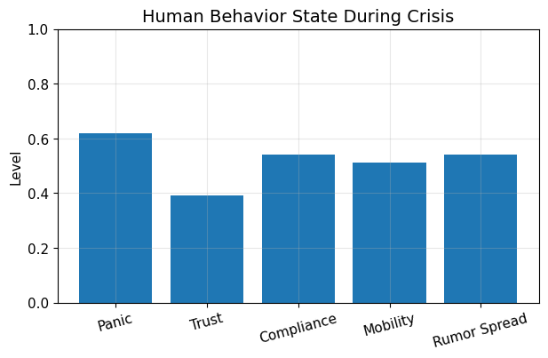

```python
plot_behavior_state(behavior)
```

```python
def plot_migration_curve():
    panic = np.linspace(0,1,100)
    migration = [migration_risk(p, 0.6, 0.6) for p in panic]

    plt.figure(figsize=(7,4))
    plt.plot(panic, migration, linewidth=2)
    plt.xlabel("Panic Level")
    plt.ylabel("Migration Risk")
    plt.title("Migration Wave Trigger Curve")
    plt.grid(alpha=0.3)
    plt.show()
```

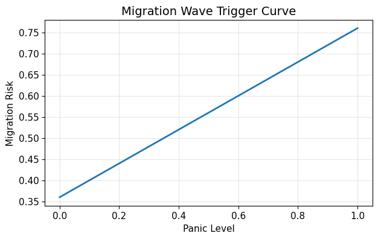

```python
plot_migration_curve()
```

```python
pip install ipywidgets pandas matplotlib numpy
```

```python
import numpy as np
import pandas as pd
import matplotlib.pyplot as plt
import ipywidgets as widgets
from IPython.display import display, clear_output
```

```python
REGIONS = {
    "Delhi": {"population_density": 0.9, "governance": 0.6},
    "Mumbai": {"population_density": 0.95, "governance": 0.55},
    "Chennai": {"population_density": 0.7, "governance": 0.6},
    "Bengaluru": {"population_density": 0.75, "governance": 0.65},
    "Assam": {"population_density": 0.4, "governance": 0.5}
}
```

```python
def load_flood_data():
    # replace with IMD / NDMA CSV later
    data = {
        "Delhi": np.linspace(0.2, 0.8, 30),
        "Mumbai": np.linspace(0.4, 0.9, 30),
        "Assam": np.linspace(0.5, 1.0, 30)
    }
    return data
```

```python
def load_pandemic_data():
    # replace with MoHFW / WHO CSV later
    data = {
        "Delhi": np.linspace(0.3, 0.6, 30),
        "Mumbai": np.linspace(0.4, 0.7, 30),
        "Assam": np.linspace(0.2, 0.5, 30)
    }
    return data
```

```python
class HumanBehavior:
    def __init__(self):
        self.panic = 0.3
        self.trust = 0.6
        self.compliance = 0.7
        self.mobility = 0.2
        self.rumor = 0.3

    def step(self, crisis, info_quality, aid):
        self.panic = min(1, self.panic + 0.45 * crisis)
        self.trust = max(0, self.trust - 0.35 * (1 - info_quality))
        self.compliance = max(0, self.compliance + 0.3 * aid - 0.4 * self.panic)
        self.mobility = min(1, self.mobility + 0.5 * self.panic)
        self.rumor = min(1, self.rumor + 0.4 * (1 - info_quality))

    def vector(self):
        return [self.panic, self.trust, self.compliance, self.mobility, self.rumor]
```

```python
def flood_severity(rainfall, density):
    return min(1.0, 0.6 * rainfall + 0.4 * density)

def pandemic_severity(infection):
    return min(1.0, infection)
```

```python
def simulate_ncb(region, crisis_type, days=30):
    behavior = HumanBehavior()
    history = []

    flood_data = load_flood_data()
    pandemic_data = load_pandemic_data()

    for day in range(days):
        if crisis_type == "Flood":
            crisis = flood_severity(
                flood_data.get(region, np.zeros(days))[day],
                REGIONS[region]["population_density"]
            )
        else:
            crisis = pandemic_severity(
                pandemic_data.get(region, np.zeros(days))[day]
            )

        behavior.step(
            crisis=crisis,
            info_quality=0.5,
            aid=0.4
        )

        history.append(behavior.vector())

    return np.array(history)
```

```python
def plot_behavior_time(history):
    labels = ["Panic", "Trust", "Compliance", "Mobility", "Rumor"]
    plt.figure(figsize=(8,4))

    for i, label in enumerate(labels):
        plt.plot(history[:, i], label=label)

    plt.ylim(0,1)
    plt.title("Human Behavior Evolution (T+0 → T+30 days)")
    plt.xlabel("Days")
    plt.ylabel("Level")
    plt.legend()
    plt.grid(alpha=0.3)
    plt.show()
```

```python
region_selector = widgets.Dropdown(
    options=list(REGIONS.keys()),
    value="Delhi",
    description="Region:"
)

crisis_selector = widgets.ToggleButtons(
    options=["Flood", "Pandemic"],
    description="Crisis:"
)

day_slider = widgets.IntSlider(
    min=0, max=29, value=0,
    description="Day:"
)

output = widgets.Output()

def update_room(change=None):
    with output:
        clear_output(wait=True)

        history = simulate_ncb(
            region_selector.value,
            crisis_selector.value
        )

        plot_behavior_time(history)

        today = history[day_slider.value]
        display(pd.Series(
            today,
            index=["Panic","Trust","Compliance","Mobility","Rumor"],
            name=f"Day {day_slider.value}"
        ))

region_selector.observe(update_room, names="value")
crisis_selector.observe(update_room, names="value")
day_slider.observe(update_room, names="value")
```

```python
display(
    widgets.VBox([
        widgets.HTML("<h2>🧠 National Crisis Brain — Jupyter Crisis Room</h2>"),
        region_selector,
        crisis_selector,
        day_slider,
        output
    ])
)

update_room()
```

```
VBox(children=(HTML(value='<h2>🧠 National Crisis Brain — Jupyter Crisis Room</h2>'), Dropdown(description='Reg…
```

```python
def migration_flow(panic, infrastructure_damage, livelihood_loss, population):
    """
    Returns estimated % of population moving
    """
    flow_ratio = min(
        1.0,
        0.4 * panic +
        0.3 * infrastructure_damage +
        0.3 * livelihood_loss
    )
    return flow_ratio * population
```

```python
def plot_migration_flows(region, outflow, destinations):
    plt.figure(figsize=(7,4))

    regions = [region] + list(destinations.keys())
    flows = [-outflow] + list(destinations.values())

    colors = ["red" if f < 0 else "green" for f in flows]

    plt.bar(regions, flows, color=colors)
    plt.axhline(0, color="black", linewidth=1)

    plt.title("Estimated Migration Flows")
    plt.ylabel("People Moving")
    plt.xticks(rotation=15)
    plt.grid(alpha=0.3)
    plt.show()
```

```python
def panic_alert(panic):
    if panic < 0.4:
        return "🟢 Stable"
    elif panic < 0.6:
        return "🟡 Rising Stress"
    elif panic < 0.8:
        return "🟠 Panic Risk"
    else:
        return "🔴 Mass Panic Imminent"
```

```python
def apply_policy(behavior, policy):
    """
    policy ∈ {"Info Campaign", "Cash Aid", "Military Logistics", "None"}
    """
    if policy == "Info Campaign":
        behavior.trust = min(1.0, behavior.trust + 0.25)
        behavior.rumor = max(0.0, behavior.rumor - 0.3)

    elif policy == "Cash Aid":
        behavior.panic = max(0.0, behavior.panic - 0.25)
        behavior.compliance = min(1.0, behavior.compliance + 0.2)

    elif policy == "Military Logistics":
        behavior.mobility = max(0.0, behavior.mobility - 0.3)
        behavior.trust = min(1.0, behavior.trust + 0.15)

    return behavior
```

```python
def simulate_ncb_with_policy(region, crisis_type, policy, days=30):
    behavior = HumanBehavior()
    history = []

    for day in range(days):
        crisis = np.random.uniform(0.4, 0.8)  # replace with real data
        behavior.step(crisis, info_quality=0.5, aid=0.4)

        if day == 10:  # intervention day
            behavior = apply_policy(behavior, policy)

        history.append(behavior.vector())

    return np.array(history)
```

```python
policy_selector = widgets.Dropdown(
    options=["None", "Info Campaign", "Cash Aid", "Military Logistics"],
    value="None",
    description="Policy:"
)

migration_output = widgets.Output()

def update_room_full(change=None):
    with output:
        clear_output(wait=True)

        history = simulate_ncb_with_policy(
            region_selector.value,
            crisis_selector.value,
            policy_selector.value
        )

        plot_behavior_time(history)

        today = history[day_slider.value]
        panic = today[0]

        display(pd.Series(
            today,
            index=["Panic","Trust","Compliance","Mobility","Rumor"],
            name=f"Day {day_slider.value}"
        ))

        display("ALERT:", panic_alert(panic))

    with migration_output:
        clear_output(wait=True)

        outflow = migration_flow(
            panic=today[0],
            infrastructure_damage=0.6,
            livelihood_loss=0.6,
            population=1_000_000
        )

        plot_migration_flows(
            region_selector.value,
            outflow,
            {"Neighbor State A": outflow*0.6, "Neighbor State B": outflow*0.4}
        )

policy_selector.observe(update_room_full, names="value")
```

```python
display(
    widgets.VBox([
        widgets.HTML("<h2>🧠 National Crisis Brain — Advanced Crisis Room</h2>"),
        region_selector,
        crisis_selector,
        policy_selector,
        day_slider,
        output,
        migration_output
    ])
)

update_room_full()
```

```
VBox(children=(HTML(value='<h2>🧠 National Crisis Brain — Advanced Crisis Room</h2>'), Dropdown(description='Re…
```

```python
def uncertainty_estimation(signal_quality, data_coverage, model_stability):
    """
    All inputs ∈ [0,1]
    Returns uncertainty ∈ [0,1]
    """
    uncertainty = (
        0.4 * (1 - signal_quality) +
        0.3 * (1 - data_coverage) +
        0.3 * (1 - model_stability)
    )
    return round(min(1.0, uncertainty), 3)


def confidence_score(uncertainty):
    """
    Converts uncertainty → confidence
    """
    return round(1.0 - uncertainty, 3)
```

```python
uncertainty = uncertainty_estimation(
    signal_quality=0.7,
    data_coverage=0.6,
    model_stability=0.65
)

confidence_score(uncertainty)
```

```
0.655
```

```python
def robustness_test(evaluate_fn, state, decision_vector, runs=100):
    outcomes = []

    for _ in range(runs):
        noise = np.random.normal(0, 0.05, size=len(decision_vector))
        noisy_decision = np.clip(decision_vector + noise, -1, 1)

        result = evaluate_fn(state, noisy_decision)
        outcomes.append(result["Strategic Stability Index"])

    return {
        "Best Case": round(max(outcomes), 3),
        "Worst Case": round(min(outcomes), 3),
        "Average": round(np.mean(outcomes), 3),
        "Volatility": round(np.std(outcomes), 3)
    }
```

```python
def regret_score(best_possible, actual):
    """
    Regret = lost stability vs best option
    """
    return round(best_possible - actual, 3)
```

```python
def misinterpretation_risk(
    signaling_clarity,
    doctrine_alignment,
    historical_tension,
    media_noise
):
    """
    All inputs ∈ [0,1]
    """
    risk = (
        0.35 * (1 - signaling_clarity) +
        0.30 * (1 - doctrine_alignment) +
        0.20 * historical_tension +
        0.15 * media_noise
    )
    return round(min(1.0, risk), 3)
```

```python
def misinterpretation_level(score):
    if score < 0.3:
        return "Low"
    elif score < 0.6:
        return "Moderate"
    else:
        return "High"
```

```python
risk = misinterpretation_risk(
    signaling_clarity=0.4,
    doctrine_alignment=0.5,
    historical_tension=0.7,
    media_noise=0.6
)

risk, misinterpretation_level(risk)
```

```
(0.59, 'Moderate')
```

```python
def hard_stop_conditions(
    confidence,
    nuclear_risk,
    misinterpretation_risk,
    min_confidence=0.5
):
    if confidence < min_confidence:
        return "STOP: Insufficient Confidence"

    if nuclear_risk > 0.7:
        return "STOP: Nuclear Miscalculation Risk"

    if misinterpretation_risk > 0.75:
        return "STOP: High Misinterpretation Risk"

    return "Proceed (Advisory Only)"
```

```python
def aide_final_decision(
    state,
    decision_vector,
    eval_fn,
    signal_quality,
    data_coverage,
    model_stability,
    misinterp_inputs
):
    base = eval_fn(state, decision_vector)

    uncertainty = uncertainty_estimation(
        signal_quality,
        data_coverage,
        model_stability
    )
    confidence = confidence_score(uncertainty)

    robustness = robustness_test(
        eval_fn,
        state,
        decision_vector
    )

    misinterp = misinterpretation_risk(**misinterp_inputs)

    stop_status = hard_stop_conditions(
        confidence,
        base.get("Nuclear Risk", 0.5),
        misinterp
    )

    return {
        "Core Outcome": base,
        "Confidence": confidence,
        "Uncertainty": uncertainty,
        "Robustness": robustness,
        "Misinterpretation Risk": misinterp,
        "Misinterpretation Level": misinterpretation_level(misinterp),
        "Decision Status": stop_status
    }
```

```python
def executive_summary(result):
    return {
        "Strategic Stability": result["Core Outcome"]["Strategic Stability Index"],
        "Confidence": result["Confidence"],
        "Worst-Case Stability": result["Robustness"]["Worst Case"],
        "Volatility": result["Robustness"]["Volatility"],
        "Misinterpretation Risk": result["Misinterpretation Level"],
        "Decision Status": result["Decision Status"]
    }
```

```python
final = aide_final_decision(
    state=None,
    decision_vector=np.array([0.1, -0.05, 0.08]),
    eval_fn=evaluate_decision_stub,   # swap with real evaluator
    signal_quality=0.65,
    data_coverage=0.6,
    model_stability=0.7,
    misinterp_inputs={
        "signaling_clarity": 0.4,
        "doctrine_alignment": 0.5,
        "historical_tension": 0.7,
        "media_noise": 0.6
    }
)

pd.Series(executive_summary(final))
```

```
Strategic Stability                      0.425649
Confidence                                   0.65
Worst-Case Stability                        0.302
Volatility                                  0.112
Misinterpretation Risk                   Moderate
Decision Status           Proceed (Advisory Only)
dtype: object
```

```python
import numpy as np
import pandas as pd
import matplotlib.pyplot as plt
import ipywidgets as widgets
from IPython.display import display, clear_output
```

```python
HISTORICAL_SCENARIOS = {
    "Cuban Missile Crisis (1962)": {
        "signal_quality": 0.4,
        "data_coverage": 0.3,
        "model_stability": 0.5,
        "misinterp": {
            "signaling_clarity": 0.2,
            "doctrine_alignment": 0.3,
            "historical_tension": 0.9,
            "media_noise": 0.4
        }
    },
    "Kargil Conflict (1999)": {
        "signal_quality": 0.6,
        "data_coverage": 0.5,
        "model_stability": 0.6,
        "misinterp": {
            "signaling_clarity": 0.4,
            "doctrine_alignment": 0.5,
            "historical_tension": 0.7,
            "media_noise": 0.3
        }
    },
    "Ukraine Escalation (2022)": {
        "signal_quality": 0.7,
        "data_coverage": 0.8,
        "model_stability": 0.7,
        "misinterp": {
            "signaling_clarity": 0.5,
            "doctrine_alignment": 0.4,
            "historical_tension": 0.8,
            "media_noise": 0.7
        }
    }
}
```

```python
def evaluate_decision_stub(state, decision_vector):
    np.random.seed(int(np.sum(np.abs(decision_vector))*1000) % 1000)
    return {
        "Escalation Risk": np.random.uniform(0.4, 0.8),
        "Alliance Risk": np.random.uniform(0.3, 0.7),
        "Nuclear Risk": np.random.uniform(0.2, 0.6),
        "Strategic Stability Index": np.random.uniform(0.3, 0.7)
    }
```

```python
mode_selector = widgets.ToggleButtons(
    options=["Live Scenario", "Historical Backtest"],
    description="Mode:"
)

scenario_selector = widgets.Dropdown(
    options=list(HISTORICAL_SCENARIOS.keys()),
    description="Scenario:"
)

decision_slider = widgets.FloatSlider(
    min=-0.2, max=0.2, step=0.02,
    value=0.05,
    description="Decision:"
)

output = widgets.Output()
```

```python
def update_crisis_room(change=None):
    with output:
        clear_output(wait=True)

        decision_vector = np.array([decision_slider.value, 0, 0])

        if mode_selector.value == "Live Scenario":
            signal_quality = 0.65
            data_coverage = 0.6
            model_stability = 0.7
            misinterp = {
                "signaling_clarity": 0.5,
                "doctrine_alignment": 0.6,
                "historical_tension": 0.6,
                "media_noise": 0.4
            }
            title = "Live AIDE Evaluation"

        else:
            s = HISTORICAL_SCENARIOS[scenario_selector.value]
            signal_quality = s["signal_quality"]
            data_coverage = s["data_coverage"]
            model_stability = s["model_stability"]
            misinterp = s["misinterp"]
            title = f"Backtest: {scenario_selector.value}"

        result = aide_final_decision(
            state=None,
            decision_vector=decision_vector,
            eval_fn=evaluate_decision_stub,
            signal_quality=signal_quality,
            data_coverage=data_coverage,
            model_stability=model_stability,
            misinterp_inputs=misinterp
        )

        summary = executive_summary(result)
        df = pd.Series(summary)

        display(widgets.HTML(f"<h3>{title}</h3>"))
        display(df)

mode_selector.observe(update_crisis_room, names="value")
scenario_selector.observe(update_crisis_room, names="value")
decision_slider.observe(update_crisis_room, names="value")
```

```python
display(
    widgets.VBox([
        widgets.HTML("<h2>🧠 AIDE Defense — Jupyter Crisis Room</h2>"),
        mode_selector,
        scenario_selector,
        decision_slider,
        output
    ])
)

update_crisis_room()
```

```
VBox(children=(HTML(value='<h2>🧠 AIDE Defense — Jupyter Crisis Room</h2>'), ToggleButtons(description='Mode:',…
```